## Linear Algebra and Programming Skills

*Dr Jon Shiach, Department of Computing and Mathematics, Manchester Metropolitan University*

# Plotting

#### Learning Outcomes

On successful completion of this page readers will be able to:

- use Python to produce line, scatter, surface and contour plots
- add axes labels, titles and legends to the plot axes;
- plot polygons;
- create image plots of pixel data;
- save plots to a file.

We can use Python to produce plots of data and save them to a file. Here we will look at how we can create the most common types of plots.

## matplotlib

**[matplotlib](https://matplotlib.org/)** is a library of functions that allows us to produce plots of data within a Python program. Like with other libraries, we need to import it using the `import` command. For example, to import the matplotlib function `pyplot` which is used for the most common plots we use

```
import matplotlib.pyplot as plt
```

This will allow us to call `pyplot` functions using the precursor `plt.`

## Figure and axis objects

Before we can produce a plot we need to create a figure object and an axis object. The simplest way to do this is to use the `plt.subplots` command ([pyplot.subplots help page](https://matplotlib.org/3.2.1/api/_as_gen/matplotlib.pyplot.subplots.html)).

```
fig, ax = plt.subplots()
```

Here `fig` and `ax` are the names we have given to the figure and axis objects respectively (think of these as variable names).

## Line plot

To plot a simple two-dimensional function we can use the `plot` command ([pyplot.plot help page](https://matplotlib.org/3.2.1/api/_as_gen/matplotlib.pyplot.plot.html)).

```
ax.plot(x, y)
```

where `ax` is the name of the axes and `x` and `y` are one-dimensional arrays.

The NumPy command `np.linspace` is useful for generating an array of `x` values ([numpy.linspace help page](https://numpy.org/devdocs/reference/generated/numpy.linspace.html)).

```
x = np.linspace(start, end, num)
```

This creates an array `x` with `num` equally spaced values between `start` and `end` inclusive.

#### Example 1

The Python code below plots the function $y=x^2$. Enter it into the code cell below and execute it to see the result (you may have to execute it a couple of times to get it to show the plot).

```
%matplotlib inline
import numpy as np
import matplotlib.pyplot as plt

x = np.linspace(-2, 2, 100)
y = x ** 2

fig, ax = plt.subplots()
ax.plot(x, y)
plt.show()
```

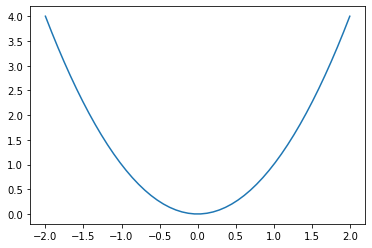

```python
%matplotlib inline
import numpy as np
import matplotlib.pyplot as plt

# Generate co-ordiante arrays
x = np.linspace(-2, 2, 50)
y = x ** 2

# Plot figure
fig, ax = plt.subplots()
ax.plot(x, y)

plt.show()
```

### Plot styles

We can change the appearance of the line by specifying the format after the co-ordinates in the `plot` command.

```
ax.plot(x, y, fmt)
```

Where `fmt` is a character string that specifies the colour, marker and line styles.

```
fmt = '[marker][line][colour]'
```

The characters for some of the marker, line and colour styles are shown in the table below. Note that these are optional, e.g., if no marker character is specified then the data will be plotted as a line without markers. Also it doesn't matter what order the characters in `fmt` are, e.g., `'r-o'` produces the same result as `'o-r'`.

| Character | Description | Character | Description | Character | Description |
| --- | --- | --- | --- | --- | --- |
| `'.'` | point marker | `'-'` | solid line | `'b'` | blue |
| `','` | pixel marker | `'--'` | dashed line | `'g'` | green |
| `'o'` | circle marker | `'-.'` | dash-dot line | `'r'` | red |
| `'v'` | triangle down marker | `':'` | dotted line | `'c'` | cyan |
| `'^'` | triangle up marker |  |  | `'m'` | magenta |
| `'s'` | square marker |  |  | `'y'` | yellow |
| `'*'` | star marker |  |  | `'k'` | black |
| `'+'` | plus marker |  |  | `'w'` | white |
| `'x'` | x marker |  |  |  |  |

#### Example 2

The Python commands below plots the same function $y=x^2$ from example 1 using a red line with a circle marking each point (the `fig` command tells Python to show the figure `fig` again so we can see the affect of the changes). Enter them into the code cell below and execute it to see the result.

```
# Plot figure
fig, ax = plt.subplots()
ax.plot(x, y, 'r-o')    # Plot red line with circle markers

display(fig)
```

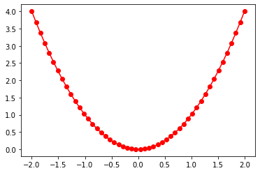

```python
# Plot figure
fig, ax = plt.subplots()
ax.plot(x, y, 'r-o')    # Plot red line with circle markers

plt.show()
```

## Changing the axes

### Axis scale

The axis scale can be adjusted using the `axis` commands ([pyplot.set_xlim help page](https://matplotlib.org/3.2.1/api/_as_gen/matplotlib.pyplot.axis.html))

```
ax.set_xlim(xmin, xmax)
ax.set_ylim(ymin, ymax)
```

where `xmin` and `xmax` are the minimum and maximum value on the $x$-axis (and similar for $y$).

### Setting the aspect ratio

We can set the aspect ratio of the plot which controls the height and with of the axes using the `set_aspect` command ([pyplot.set_aspect help page](https://matplotlib.org/3.1.1/api/_as_gen/matplotlib.axes.Axes.set_aspect.html))

```
ax.set_aspect(value)
```

Here `value` is either `'auto'`, `'equal'` or `num` as described in the table below.

| value | description |
| --- | --- |
| `'auto'` | automatic; fill the position rectangle with data |
| `'equal'` | same scaling from data to plot units for $x$ and $y$ |
| `num` | a circle will be stretched such that the height is `num` times the width |

#### Example 3

The commands below change the axis limits and aspect ratio to the plot from example 2. Enter them into the code cell below and execute it to see the result.

```
# Configure axes
ax.set_xlim(-1, 1)     # set x axis range to [-1, 1]
ax.set_ylim(-1, 2)     # set y axis range to [-1, 2]
ax.set_aspect('equal') # set aspect ratio to 'equal'

plt.show()
```

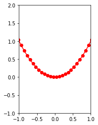

```python
# Configure axes
ax.set_xlim(-1, 1)     # set x axis range to [-1, 1]
ax.set_ylim(-1, 2)     # set y axis range to [-1, 2]
ax.set_aspect('equal') # set aspect ratio to 'equal'

display(fig)
```

## Axis labels and title

Axis labels and titles can be added to a plot using the `set_xlabel`, `set_ylabel` and `set_title` commands ([set_xlabel help page](https://matplotlib.org/3.2.1/api/_as_gen/matplotlib.axes.Axes.set_xlabel.html), [set_title help page](https://matplotlib.org/3.2.1/api/_as_gen/matplotlib.axes.Axes.set_title.html)).

```
ax.set_xlabel('x axis label', fontsize=size)
ax.set_ylabel('y axis label', fontsize=size)
ax.set_title('plot title', fontsize=size)
```

Where `fontsize=size` is optional and specifies fontsize in pt.

#### Example 4

The following commands add axis labels and title to the plot from example 2. Enter them into the code cell below and execute it to see the result.

```
# Plot figure
fig, ax = plt.subplots()
ax.plot(x, y, 'r-o')

# Configure axes
ax.set_xlabel('x', fontsize=12)      # x axis label
ax.set_ylabel('y', fontsize=12)      # y axis label
ax.set_title('y = x^2', fontsize=12) # plot title

plt.show()
```

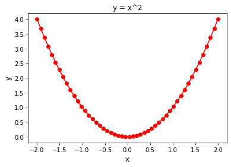

```python
# Plot figure
fig, ax = plt.subplots()
ax.plot(x, y, 'r-o')

# Configure axes
ax.set_xlabel('x', fontsize=12)      # x axis label
ax.set_ylabel('y', fontsize=12)      # y axis label
ax.set_title('y = x^2', fontsize=12) # plot title

plt.show()
```

## Saving a plot to file

We can save a figure to a file so that we can import it into other documents using the `savefig` command ([pyplot.savefig help page](https://matplotlib.org/3.2.1/api/_as_gen/matplotlib.pyplot.savefig.html)).

[output not shown]

Where `filename` includes the extension for the image type used. Most common image formats are supported, e.g., png, jpeg, svg etc., but png (Portable Network Graphics) files are preferred for importing into electronic documents.

#### Example 5

The command below saves the figure `fig` as a png file using the file name `myplot.png`. Enter it into the code cell below and execute it. Check that an image file containing your plot has been produced and open it to see the result.

```
fig.savefig('myplot.png')    # save plot to file
```

```python
fig.savefig('myplot.png')    # save plot to file
```

## Exercise 1

1. Reproduce the plot of $y=\sin(x)$ over the domain $x\in [-2\pi, 2\pi]$ shown below

[figure not shown]

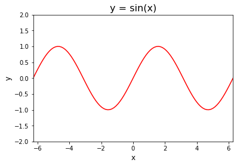

```python
x = np.linspace(-2 * np.pi, 2 * np.pi, 100)
y = np.sin(x)

fig, ax = plt.subplots()
ax.plot(x, y, 'r-')

ax.set_xlim(-2 * np.pi, 2 * np.pi)
ax.set_ylim(-2, 2)
ax.set_aspect(2)
ax.set_xlabel('x', fontsize=12)
ax.set_ylabel('y', fontsize=12)
ax.set_title('y = sin(x)', fontsize=16)

plt.show()
fig.savefig('sinx.png')
```

1. Produce a plot of the function $y=x^2-3x+2$ over the domain $x\in [0,10]$.

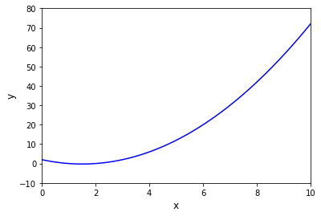

```python
x = np.linspace(0, 10, 100)
y = x ** 2 - 3 * x + 2

fig, ax = plt.subplots()
ax.plot(x, y, 'b-')

ax.set_xlim(0, 10)
ax.set_ylim(-10, 80)
ax.set_xlabel('x', fontsize=12)
ax.set_ylabel('y', fontsize=12)

plt.show()
```

1. Produce a plot of the function $s=2t^3 + 3t^2 - 8t + 6$ over the domain $t\in [-4,4]$ using a green line. Scale the $s$-axis so that it is in the range $[-50,50]$.

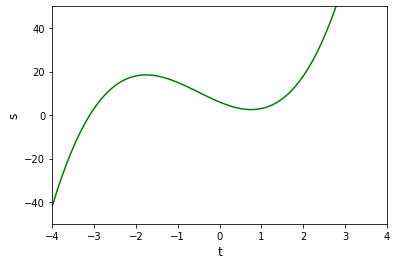

```python
t = np.linspace(-4, 4, 100)
s = 2 * t ** 3 + 3 * t ** 2 - 8 * t + 6

fig, ax = plt.subplots()
ax.plot(t, s, 'g-')

ax.set_xlim(-4, 4)
ax.set_ylim(-50, 50)
ax.set_xlabel('t', fontsize=12)
ax.set_ylabel('s', fontsize=12)

plt.show()
```

## Multiple plots on the same axes

To include multiple plots on the same axis simply add another `plot` command.

```
ax.plot(x1, y1) # first plot
ax.plot(x2, y2) # second plot
```

#### Example 6

The commands below plots the three functions $y=x^2$, $y=x^3$ and $y=x^4$ over the domain $x\in[-2,2]$ on the same set of axes. Enter them into the code cell below and execute it to see the result.

```
# Generate co-ordinate arrays
x = np.linspace(-2, 2, 100)
y1 = x ** 2     # first function
y2 = x ** 3     # second function
y3 = x ** 4     # third function

# Plot functions
fig, ax = plt.subplots()
ax.plot(x, y1, '-r') # first plot
ax.plot(x, y2, '-b') # second plot
ax.plot(x, y3, '-k') # third plot

# Configure axes
ax.set_xlabel('x', fontsize=12)
ax.set_ylabel('y', fontsize=12)

plt.show()
```

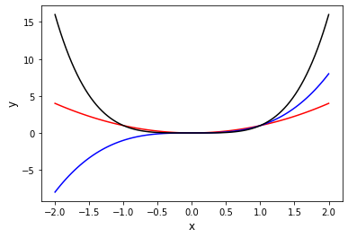

```python
# Generate co-ordinate arrays
x = np.linspace(-2, 2, 100)
y1 = x ** 2     # first function
y2 = x ** 3     # second function
y3 = x ** 4     # third function

# Plot functions
fig, ax = plt.subplots()
ax.plot(x, y1, '-r') # first plot
ax.plot(x, y2, '-b') # second plot
ax.plot(x, y3, '-k') # third plot

# Configure axes
ax.set_xlabel('x', fontsize=12)
ax.set_ylabel('y', fontsize=12)

plt.show()
```

## Adding a legend to a plot

A legend can be added to a plot using the `legend` command ([pyplot.legend help page](https://matplotlib.org/3.2.1/api/_as_gen/matplotlib.pyplot.legend.html)) but first we need to add a label to each `plot` command.

```
ax.plot(x, y1, label='1st plot label')
ax.plot(x, y2, label='2nd plot label')
```

Once the individual plots have labels associated with them we can add a legend using

```
ax.legend(fontsize=size, loc=location)
```

Where `fontsize` and `loc` are optional arguments. `location` is a character string from one of `'best'` (places the legend in one of the following nine locations with minimum overlap with the drawn plots), `'uppper left'`, `'upper center`, `upper right'`, `'left'`, `'center'`, `'right'`, `'lower left'`, `'lower center'` and `'lower right'`

#### Example 7

The commands below add a legend to the plot from example 6. Enter them into the code cell below and execute it to see the result.

```
# Plot functions
fig, ax = plt.subplots()
ax.plot(x, y1, '-r', label='y = x^2') # first plot
ax.plot(x, y2, '-b', label='y = x^3') # second plot
ax.plot(x, y3, '-k', label='y = x^4') # third plot

# Configure axes
ax.set_xlabel('x', fontsize=12)
ax.set_ylabel('y', fontsize=12)
ax.legend()

plt.show()
```

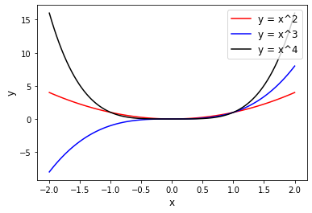

```python
# Plot functions
fig, ax = plt.subplots()
ax.plot(x, y1, '-r', label='y = x^2') # first plot
ax.plot(x, y2, '-b', label='y = x^3') # second plot
ax.plot(x, y3, '-k', label='y = x^4') # third plot

# Configure axes
ax.set_xlabel('x', fontsize=12)
ax.set_ylabel('y', fontsize=12)
ax.legend(fontsize=12, loc='upper right')

plt.show()
```

Note that in this case the location of the legend in the upper right hand corner overlaps with part of the plot and is not the best location to put the legend.

## Exercise 2

1. Reproduce the plot below of $y=\sin(x)$ and $y=\cos(x)$ over the domain $x\in[-2\pi, 2\pi]$ on the same set of axes.

[figure not shown]

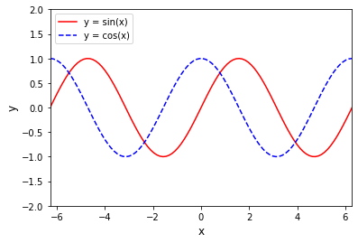

```python
x = np.linspace(-2 * np.pi, 2 * np.pi, 100)
y1 = np.sin(x)
y2 = np.cos(x)

fig, ax = plt.subplots()
ax.plot(x, y1, 'r-', label='y = sin(x)')
ax.plot(x, y2, 'b--', label='y = cos(x)')

ax.set_xlim(-2 * np.pi, 2 * np.pi)
ax.set_ylim(-2, 2)
ax.set_xlabel('x', fontsize=12)
ax.set_ylabel('y', fontsize=12)
ax.legend(loc='upper left')

plt.show()
fig.savefig('sinx_cosx.png')
```

1. The points on a circle centred at $(c_x,c_y)$ with radius $r$ can be calculated using $(x,y) = (c_x,c_y) + r(\cos(\theta), \sin(\theta))$ for $\theta\in [0,2\pi]$. Plot four circles centred at $(5, 5)$ with radii $r=1,2,3,4$. Use an `set_aspect` command to display the circles in the correct aspect ratio (i.e., they look like circles and not ellipses).

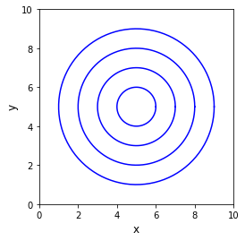

```python
cx, cy = 5, 5
theta = np.linspace(0, 2 * np.pi, 100)

fig, ax = plt.subplots()
for r in range(1, 5):
    x = cx + r * np.cos(theta)
    y = cy + r * np.sin(theta)
    ax.plot(x, y, 'b-')

ax.set_xlim(0, 10)
ax.set_ylim(0, 10)
ax.set_aspect('equal')
ax.set_xlabel('x', fontsize=12)
ax.set_ylabel('y', fontsize=12)

plt.show()
```

## Scatter plots

Scatter plots can be produced using the `scatter` command ([pyplot.scatter help page](https://matplotlib.org/3.2.1/api/_as_gen/matplotlib.pyplot.scatter.html))

```
ax.scatter(x, y, color=[colour], marker=[marker style])
```

Where `x` and `y` are one-dimensional co-ordinate arrays and `[colour]` and `[marker style]` are characters (see Plot Styles section)

#### Example 8

The following commands produce a scatter plot of 100 random points with co-ordinates in the range $x,y\in[0, 1]$. Enter them into the code cell below and execute it to see the result.

```
# Generate co-ordinate arrays
x = np.random.rand(100, 1)
y = np.random.rand(100, 1)

# Plot scatterplot
fig, ax = plt.subplots()
ax.scatter(x, y, color='r', marker='o')

# Configure axes
ax.set_xlim(0, 1)
ax.set_ylim(0, 1)
ax.set_xlabel('x', fontsize=12)
ax.set_ylabel('y', fontsize=12)

plt.show()
```

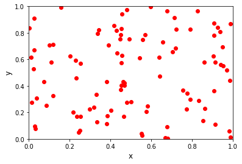

```python
# Generate co-ordinate arrays
x = np.random.rand(100, 1)
y = np.random.rand(100, 1)

# Plot scatterplot
fig, ax = plt.subplots()
ax.scatter(x, y, color='r', marker='o')

# Configure axes
ax.set_xlim(0, 1)
ax.set_ylim(0, 1)
ax.set_xlabel('x', fontsize=12)
ax.set_ylabel('y', fontsize=12)

plt.show()
```

## Exercise 3

1. Reproduce the scatter plot shown below using the values of `x` and `y` provided.

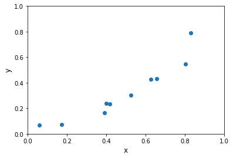

```python
x = np.array([ 0.1734, 0.3909, 0.8314, 0.8034, 0.0605, \
              0.3993, 0.5269, 0.4168, 0.6569, 0.6280 ])
y = np.array([ 0.0717, 0.1665, 0.7881, 0.5486, 0.0702, \
              0.2382, 0.3031, 0.2341, 0.4335, 0.4265 ])

fig, ax = plt.subplots()
ax.scatter(x, y)

ax.set_xlim(0, 1)
ax.set_ylim(0, 1)
ax.set_xlabel('x', fontsize=12)
ax.set_ylabel('y', fontsize=12)

plt.show()
```

1. We can calculate a line of bets fit for the data from question 6 using a linear regression model $y=mx+c$ where $m$ is the slope of the line and $c$ is the $y$-intercept. We can rewrite the linear model as $\mathbf{y}=A\mathbf{p}$ where $\mathbf{y} = (y_1, y_2, \ldots, y_n)^T$, $\mathbf{p} = (m, c)^T$ and  
   \begin{align*} A= \begin{pmatrix} x_1 & 1 \\ x_2 & 1 \\ \vdots & \vdots \\ x_n & 1 \end{pmatrix}. \end{align*}

We can then solve for $m$ and $c$ using the Numpy command `np.linalg.lstsq` which calculates the [least squares](https://en.wikipedia.org/wiki/Least_squares) solution which minimises the difference between the points $(x_i,y_i)$ and the line $y=mx+c$.

```
m, c = np.linalg.lstsq(A, y, rcond=None)[0]
```

Define the array `A`, calculate the line of best fit for the data from question 6 and add it to your scatter plot.

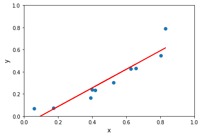

```
The line of best fit is y = 0.8394x + -0.0822.
```

```python
# Calculate line of best fit
A = np.ones((10,2))
A[:,0] = x
m, c = np.linalg.lstsq(A, y, rcond=None)[0]

# Plot data
fig, ax = plt.subplots()
ax.scatter(x, y)
ax.plot(x, m*x + c, 'r-')

ax.set_xlim(0, 1)
ax.set_ylim(0, 1)
ax.set_xlabel('x', fontsize=12)
ax.set_ylabel('y', fontsize=12)

plt.show()

print('The line of best fit is y = {:0.4f}x + {:0.4f}.'.format(m, c))
```

## 3D plots

To create a 3D plot we first need to create a 3D axis using the `Axes3D` toolkit which is done using the following commands.

```
from mpl_toolkits.mplot3d import Axes3D

fig = plt.figure()
ax = fig.gca(projection='3d')
```

### Surface plot

3D surface plots can be generated using the `plot_surface` command ([Axes3D.plot_surface help page](https://matplotlib.org/mpl_toolkits/mplot3d/tutorial.html#surface-plots)).

```
ax.plot_surface(X, Y, Z, cmap='jet', antialiased=False, edgecolor='k', linewidth=0.1)
```

where `X`, `Y` and `Z` are two-dimensional co-ordinate arrays. The optional arguments are:

- `cmap='jet'` applies the `jet` colormap
- `antialiased=False` ensures the surface is opaque
- `edgecolor='k'` draws the edges of the polygons that make up the surface
- `linewidth=0.1` reduces the width of the edges

To produce a surface plot of the bivariate function $z=f(x,y)$ we require $x$ and $y$ co-ordinates in the domain. The `np.meshgrid` command is useful for generating these ([numpy.meshgrid help page](https://numpy.org/doc/stable/reference/generated/numpy.meshgrid.html?highlight=meshgrid#numpy.meshgrid)).

```
X, Y = np.meshgrid(x co-ordinate array, y co-ordinate array)
```

#### Example 9

The Python commands below generates two $4\times 6$ element matrixes `X` and `Y` containing the co-ordinates of points in the domain $\{(x, y):x, y \in \mathbb{R}, 0\leq x \leq 5, 0 \leq y \leq 6\}$ using an increment of 1 in the $x$ direction and 2 in the $y$ direction. Enter it into the code cell below and execute it to see the result.

```
x = np.arange(0, 6, 1)
y = np.arange(0, 7, 2)
X, Y = np.meshgrid(x, y)

print(X, end="\n\n")
print(Y)
```

```python
x = np.arange(0, 6, 1)
y = np.arange(0, 7, 2)
X, Y = np.meshgrid(x, y)

print(X, end="\n\n")
print(Y)
```

```
[[0 1 2 3 4 5]
 [0 1 2 3 4 5]
 [0 1 2 3 4 5]
 [0 1 2 3 4 5]]

[[0 0 0 0 0 0]
 [2 2 2 2 2 2]
 [4 4 4 4 4 4]
 [6 6 6 6 6 6]]
```

#### Example 10

The Python code below produces a surface plot of the two-dimensional surface $z=\sin(x) + \cos(y)$ over the domain $x,y\in [0, 4\pi]$. Enter it into the code cell below and execute it to see the result.

```
from mpl_toolkits.mplot3d import Axes3D

# Generate co-ordinate arrays
x = np.linspace(0, 4*pi, 50)
y = np.linspace(0, 4*pi, 50)
X, Y = np.meshgrid(x, y)
Z = np.sin(X) + np.cos(Y)

# Plot surface
fig = plt.figure()
ax = fig.gca(projection='3d')
ax.plot_surface(X, Y, Z, cmap='jet', antialiased=False, edgecolor='k', linewidth=0.1)

# Configure axes
ax.set_xlim(0, 4*pi)
ax.set_ylim(0, 4*pi)
ax.set_zlim(-3, 3)
ax.set_xlabel('x')
ax.set_ylabel('y')
ax.set_zlabel('z')

plt.show()
```

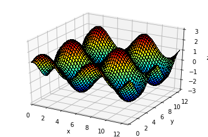

```python
from mpl_toolkits.mplot3d import Axes3D

# Generate co-ordinate arrays
x = np.linspace(0, 4 * np.pi, 50)
y = np.linspace(0, 4 * np.pi, 50)
X, Y = np.meshgrid(x, y)
Z = np.sin(X) + np.cos(Y)

# Plot surface
fig = plt.figure()
ax = fig.gca(projection='3d')
ax.plot_surface(X, Y, Z, cmap='jet', antialiased=False, edgecolor='k',
                linewidth=0.1)

# Configure axes
ax.set_xlim(0, 4 * np.pi)
ax.set_ylim(0, 4 * np.pi)
ax.set_zlim(-3, 3)
ax.set_xlabel('x')
ax.set_ylabel('y')
ax.set_zlabel('z')

plt.show()
```

### View angle

With 3D plots we can control the position of the viewpoint using the `view_init` command

```
ax.view_init(elevation, azimuth)
```

where `elevation` and `azimuth` are the angles (in degrees) that specify the vertical and horizontal position of the viewpoint relative to the centre of view.

[figure not shown]

#### Example 11

The Python commands below changes the surface plot produced in example 10 so that it is viewed from the viewpoint with elevation $45^\circ$ and azimuth $15^\circ$. Enter it into the code cell below and execute it to see the result.

```
# Specify viewing position
ax.view_init(45, 15)

display(fig)
```

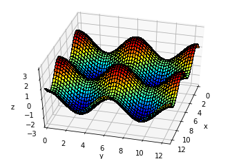

```python
# Specify viewing position
ax.view_init(45, 15)

display(fig)
```

## Exercise 4

1. Reproduce the surface plot below of the function $z=\exp(-20((x-0.5)^2 + (y-0.5)^2))$ over the domain $x, y \in [0, 1]$.

[figure not shown]

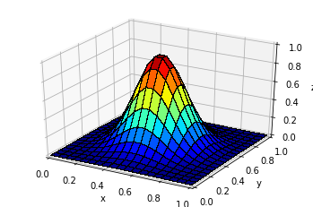

```python
# Generate co-ordinate arrays
x = np.linspace(0, 1, 20)
y = np.linspace(0, 1, 20)
X, Y = np.meshgrid(x, y)
Z = np.exp(-20*((X - 0.5)**2 + (Y-0.5)**2))

# Plot surface
fig = plt.figure()
ax = fig.gca(projection='3d')
ax.plot_surface(X, Y, Z, cmap='jet', antialiased=False, edgecolor='k', linewidth=0.01)

# Set axis
ax.set_xlim(0, 1)
ax.set_ylim(0, 1)
ax.set_zlim(0, 1)
ax.set_xlabel('x')
ax.set_ylabel('y')
ax.set_zlabel('z')

plt.show()
```

## Contour plots

Contour plots show points of equal value can be produced using the `contour` command ([pyplot.contour help page](https://matplotlib.org/3.1.1/api/_as_gen/matplotlib.pyplot.contour.html)).

```
ax.contour(X, Y, Z)
```

### Example 12

The Python commands below produces a contour plot of the same bivariate function used in example 10. Enter it into the code cell below and execute it to see the result.

```
# Generate co-ordinate arrays
x = np.linspace(0, 4 * np.pi, 100)
y = np.linspace(0, 4 * np.pi, 100)
X, Y = np.meshgrid(x, y)
Z = np.sin(X) + np.cos(Y)

# Contour plot
fig, ax = plt.subplots()
ax.contour(X, Y, Z)

# Configure axes
ax.set_xlim(0, 4 * np.pi)
ax.set_ylim(0, 4 * np.pi)
ax.set_xlabel('x')
ax.set_ylabel('y')

plt.show()
```

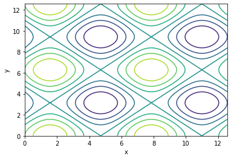

```python
# Generate co-ordinate arrays
x = np.linspace(0, 4*np.pi, 100)
y = np.linspace(0, 4*np.pi, 100)
X, Y = np.meshgrid(x, y)
Z = np.sin(X) + np.cos(Y)

# Contour plot
fig, ax = plt.subplots()
ax.contour(X, Y, Z)

# Configure axes
ax.set_xlim(0, 4*np.pi)
ax.set_ylim(0, 4*np.pi)
ax.set_xlabel('x')
ax.set_ylabel('y')

plt.show()
```

## Exercise 5

1. Produce a contour plot of the function $z=(z_1-z_2)^2$ where $z_1=\exp(-x^2-y^2)$ and $z_2=\exp(-(x-1)^2-(y-1)^2)$ over the domain $x,y\in[-2,3]$.

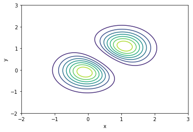

```python
# Generate co-ordinate arrays
x = np.linspace(-2, 3, 100)
y = np.linspace(-2, 3, 100)
X, Y = np.meshgrid(x, y)
Z1 = np.exp(-X**2 - Y**2)
Z2 = np.exp(-(X - 1)**2 - (Y - 1)**2)
Z = (Z1 - Z2)**2

# Contour plot
fig, ax = plt.subplots()
ax.contour(X, Y, Z)

# Configure axes
ax.set_xlim(-2, 3)
ax.set_ylim(-2, 3)
ax.set_xlabel('x')
ax.set_ylabel('y')

plt.show()
```

## Image plots

Image plots (also known as raster plots) are plots which consist of an array of small squares called pixels. In Python image plots can be produced using the `imshow` commands ([pyplot.imshow help page](https://matplotlib.org/3.2.1/api/_as_gen/matplotlib.pyplot.imshow.html)).

```
plt.imshow(img)
```

Where `img` is a NumPy array one of the following forms:

- A $m\times n$ array of values;
- A $m \times n \times 3$ array of [RGB values](https://en.wikipedia.org/wiki/RGB_color_model) either floating point values in the range $[0,1]$ or integers in the range $[0,255]$.

#### Example 13

The following commands generate a random array of $10\times 10$ pixels and plots them using the `imshow` command. Enter them into the code cell below and execute it.

```
img = np.random.rand(10, 10)

imgplot = plt.imshow(img, cmap='jet')
```

The optional command `cmap='jet'` applies the `jet` colormap.

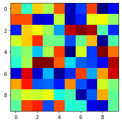

```python
img = np.random.rand(10, 10)

imgplot = plt.imshow(img, cmap='jet')
```

### Reading an image file into a NumPy array

We can read in an image file into $m\times n \times 3$ NumPy array using the `imread` command from the `matplotlib.image` library ([image.imread help page](https://matplotlib.org/api/_as_gen/matplotlib.pyplot.imread.html)).

```
import matplotlib.image as mpimg
img = mpimg.imread(filename)
```

Where `filename` is the name of the image file. This allows us to perform image manipulation operations on the image.

#### Example 14

The Python commands below reads in the pixel data from this image, determines the size of the image and plots it using the `imshow` command. Enter them into the code cell below and execute it to see the result.

```
# Read in image data
img = mpimg.imread('../Images/flower.jpg')

# Determine figure size based on the image size
dpi = 80
height, width, nbands = img.shape
figsize = height / float(dpi), width / float(dpi)

# Plot image data
fig = plt.subplots(figsize=figsize)
imgplot = plt.imshow(img)
```

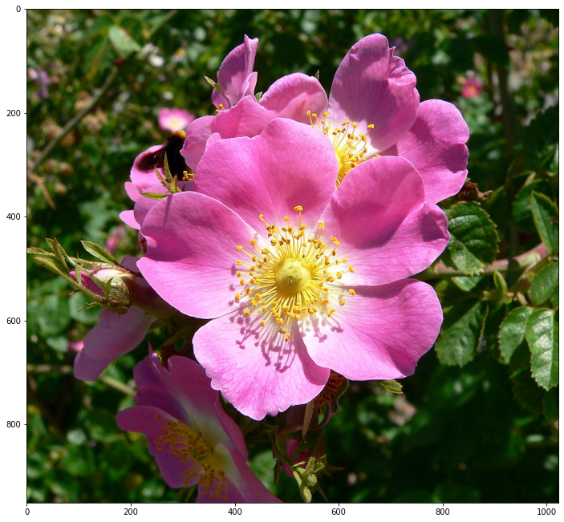

```python
import matplotlib.image as mpimg

# Read in image data
img = mpimg.imread('../Images/flower.jpg')

# Determine figure size based on the image size
dpi = 80
height, width, nbands = img.shape
figsize = height / float(dpi), width / float(dpi)

# Plot image data
fig = plt.subplots(figsize=figsize)
imgplot = plt.imshow(img)
```

## Exercise 6

1. Use two nested `for` loops to generate a $11 \times 11$ array `X` where the value of each element is the distance from the centre element, i.e., $$[X]_{ij} = \sqrt{(i-6)^2 + (j-6)^2}.$$ Plot `X` using the `image` command.

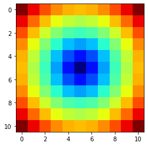

```python
X = np.zeros((11, 11))
for i in range(11):
    for j in range(11):
        X[i,j] = np.sqrt((i - 5) ** 2 + (j - 5) ** 2)

imgplot = plt.imshow(X, cmap='jet')
```

1. Load the data from the image `central_library.jpg` into a NumPy array, determine the number of pixels in the image and plot the image.

```
The image is made up of 800 pixels in the horizontal direction and 562 pixels in the
vertical direction.
```

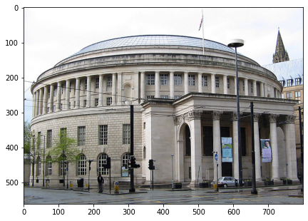

```python
# Read in image data
img = mpimg.imread('central_library.jpg')

# Determine figure size based on image size
dpi = 80
height, width, nbands = img.shape
figsize = height / float(dpi), width / float(dpi)

# Plot image data
fig = plt.subplots(figsize=figsize)
imgplot = plt.imshow(img)

print('The image is made up of {} pixels in the horizontal direction ' \
     'and {} pixels in the \nvertical direction.'.format(width, height))
```